# Emory Spring 2021 COVID Model

A model analysis of COVID-19 tranmssion and control at Emory University

10/5/2020

## Authors

*Ben Lopman, PhD. Carol Liu, MSc. Timothy Lash, DSc. Sam Jenness, PhD*

**Department of Epidemiology, Rollins School of Public Health** **Emory University**

## Summary

Emory University is exploring prevention and control strategies for the Spring 2021 school semester in response to the COVID-19 pandemic. A key question is to understand the impact of screening strategies targeting on-campus students. To provide a framework to address this question, we use an susceptible-exposed-infectious-recovered (SEIR) type of deterministic model developed for the spring semester. Compared to a static model, this approach has the advantage that it captures the transmission process, therefore estimates the indirect (transmission-mediated) effects of control strategies. For example, by testing and identifying COVID-19 infected students, the model captures the effects of them being isolated, their contacts being quarantined, as well as all the infections averted by preventing the chains of transmission that would have otherwise occurred.

## Interventions

Here we present three scenarios detailed below

| Intervention | Screening on-campus students | Screening off-campus & staff |
| --- | --- | --- |
| No screening | None | None |
| Weekly screening | Weekly | None |
| Biweekly screening | Biweekly | None |

## Parameters

This table shows the parameter inputs into the model and their ranges used in sensitivity analysis. The ‘value’ column shows our base case scenario for what we expect to be the most likely set of conditions and interventions.

| Parameter | Value | Lower | Upper |
| --- | --- | --- | --- |
| Populations |  |  |  |
| Total students | 12,000 |  |  |
| Students living on campus | 2,000 |  |  |
| Staff and faculty | 15,000 |  |  |
| Natural history and clinical |  |  |  |
| Latent period (days) | 3 | 2 | 4 |
| Infectious period (days) | 7 | 6 | 8 |
| Proportion severe - students | 0.0224 | 0.0133 | 0.0456 |
| Proportion severe - staff/faculty | 0.055 | 0.0327 | 0.1122 |
| Proportion fatal - students | 0.0002 | 0.00007 | 0.0003 |
| Proportion fatal - staff/faculty | 0.0052 | 0.0029 | 0.0105 |
| Proportion symptomatic - students | 0.35 | 0.27 | 0.43 |
| Proportion symptomatic - staff/faculty | 0.51 | 0.41 | 0.59 |
| Testing and quarantine |  |  |  |
| Time from onset of infectiousness to testing (1/days) | 2 | 7 | 1 |
| Screening frequency (1/days) | 7 | None | 3.5 |
| Duration of quarantine (days) | 14 |  |  |
| Number of contacts per case | 2 | 1 | 7 |
| Proportion of contacts reached | 0.75 | 0.5 | 1 |
| Proportion experiencing ILI symptoms per day | 0.00333 | 0.003 | 0.003667 |
| PCR Sensitivity |  |  |  |
| Day 2 of infectiousness | 0.75 | 0.6 | 0.83 |
| Day 4 of infectiousness | 0.8 | 0.7 | 0.85 |
| Day 7 of infectiousness | 0.75 | 0.65 | 0.8 |
| Transmission |  |  |  |
| All students <-> all students | 2 | 0.7 | 2.5 |
| On campus students <-> On campus students | 1 | 0.3 | 1.4 |
| All students <-> staff/faculty | 0.5 | 0.15 | 0.7 |
| Staff/faculty <-> staff/faculty | 0.5 | 0.15 | 0.7 |
| Daily rate of community introduction | 0.00026 | 0.00007 | 0.00045 |
| Risk reduction of NPIs | 0.35 | 0.18 | 0.43 |
| Time |  |  |  |
| Semester Duration (days) | 102 |  |  |

## Plots for all scenarios

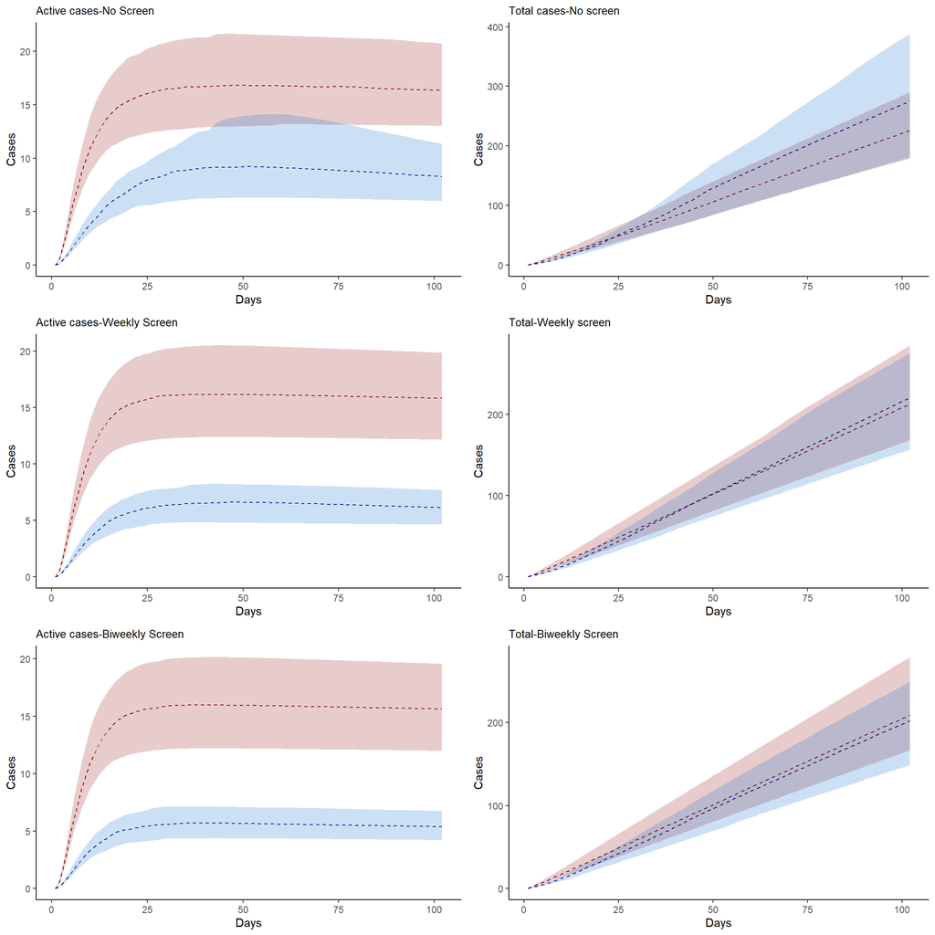